# Multiple linear regression - `trees` dataset (solved)

## Problem 8.6

The R dataset **trees** contains girth (diameter), height and volume (of boardfeet) measurements for several trees of a species of cherry tree. Describe the distribution of each of these 3 variables. Are any long tailed, short-tailed, skewed?

```r
# load the data
data(trees) # this is a dataframe
class(trees)
```

```
[1] "data.frame"
```

```r
head(trees)
```

|  | Girth | Height | Volume |
| --- | --- | --- | --- |
| 1 | 8.3 | 70 | 10.3 |
| 2 | 8.6 | 65 | 10.3 |
| 3 | 8.8 | 63 | 10.2 |
| 4 | 10.5 | 72 | 16.4 |
| 5 | 10.7 | 81 | 18.8 |
| 6 | 10.8 | 83 | 19.7 |

```r
str(trees)
```

```
'data.frame':   31 obs. of  3 variables:
 $ Girth : num  8.3 8.6 8.8 10.5 10.7 10.8 11 11 11.1 11.2 ...
 $ Height: num  70 65 63 72 81 83 66 75 80 75 ...
 $ Volume: num  10.3 10.3 10.2 16.4 18.8 19.7 15.6 18.2 22.6 19.9 ...
```

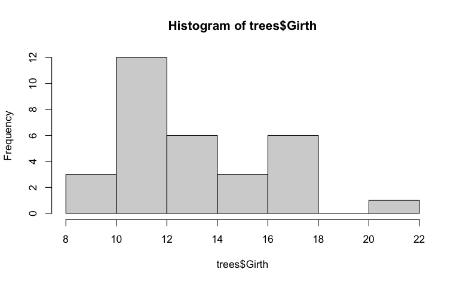

```r
# histograms
hist(trees$Girth)
```

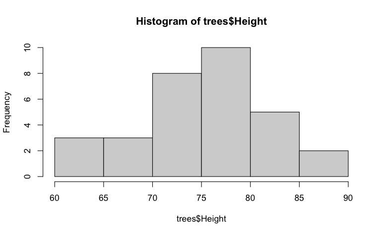

```r
hist(trees$Height)
```

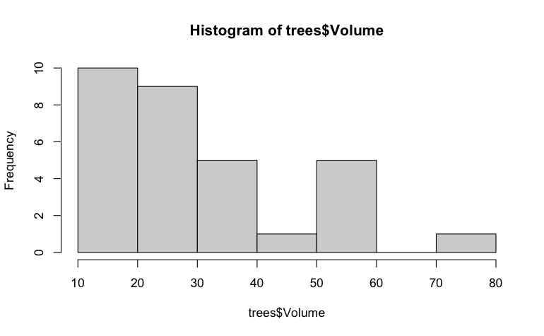

```r
hist(trees$Volume)
```

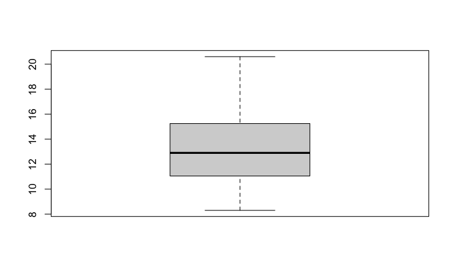

```r
# boxplots
boxplot(trees$Girth)
```

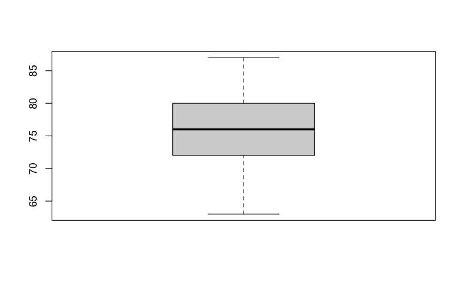

```r
boxplot(trees$Height)
```

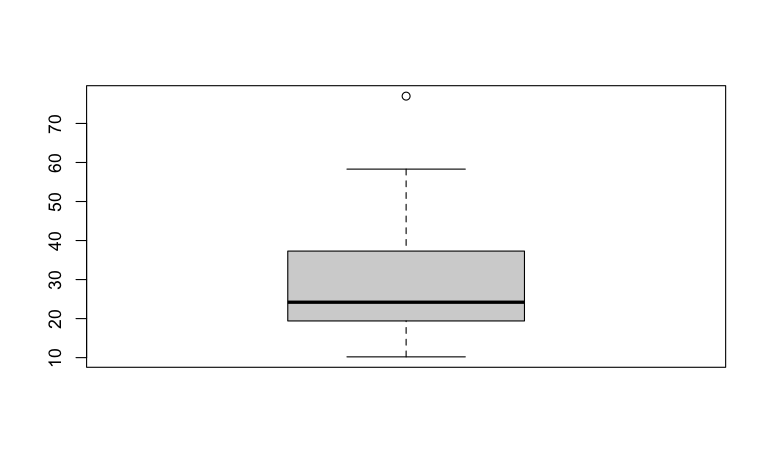

```r
boxplot(trees$Volume)
```

The graphs show us that the distributions are not symmetric (maybe just Height looks quite good, and the boxplot seems also ok for Girth…). We test for normality:

```r
# normality test
shapiro.test(trees$Girth)
```

```
    Shapiro-Wilk normality test

data:  trees$Girth
W = 0.94117, p-value = 0.08893
```

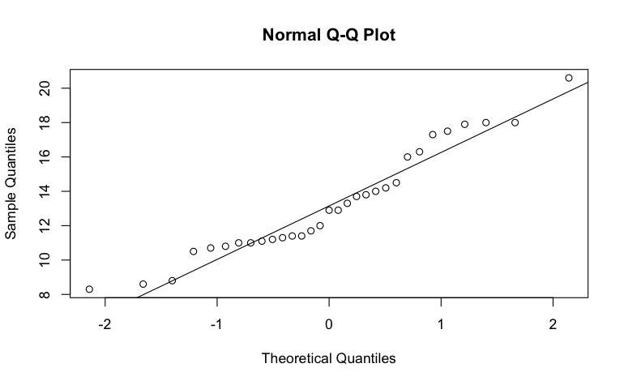

```r
qqnorm(trees$Girth); qqline(trees$Girth)
```

```r
# normality test
shapiro.test(trees$Height)
```

```
    Shapiro-Wilk normality test

data:  trees$Height
W = 0.96545, p-value = 0.4034
```

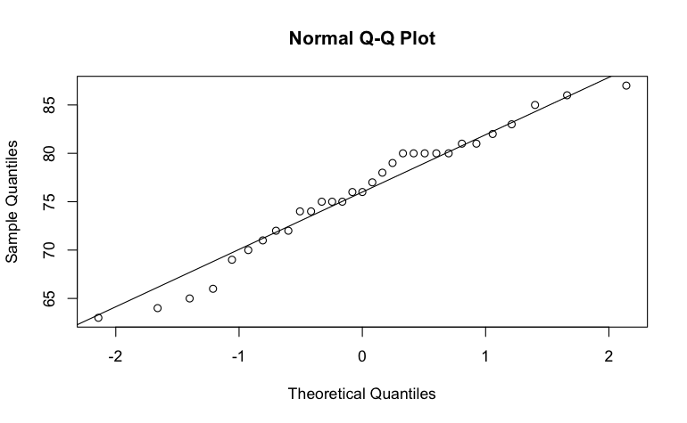

```r
qqnorm(trees$Height); qqline(trees$Height)
```

```r
# normality test
shapiro.test(trees$Volume)
```

```
    Shapiro-Wilk normality test

data:  trees$Volume
W = 0.88757, p-value = 0.003579
```

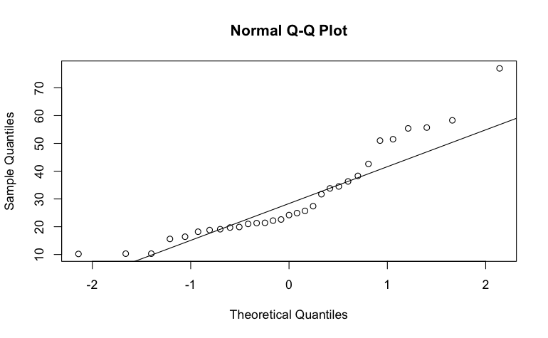

```r
qqnorm(trees$Volume); qqline(trees$Volume)
```

The Shapiro test is significant for Volume: **the distribution of this latter variable is not normal and it is positive skewed**!

## Multiple linear regression

We use a dataset of girth (diameter, in inches), height, and volume for black cherry trees. Measurements were made in 31 felled black cherry trees. The data are in the *datasets* package.

```r
data("trees")
```

Does the volume depends on girth and height? What is the mean volume of trees when girth and height are zero? What is the mean increase in volume when there is a one-unit increase in girth?

```r
mod <- lm(Volume ~ Girth + Height, data=trees)
summary(mod)
```

```
Call:
lm(formula = Volume ~ Girth + Height, data = trees)

Residuals:
    Min      1Q  Median      3Q     Max
-6.4065 -2.6493 -0.2876  2.2003  8.4847

Coefficients:
            Estimate Std. Error t value Pr(>|t|)
(Intercept) -57.9877     8.6382  -6.713 2.75e-07 ***
Girth         4.7082     0.2643  17.816  < 2e-16 ***
Height        0.3393     0.1302   2.607   0.0145 *
---
Signif. codes:  0 ‘***’ 0.001 ‘**’ 0.01 ‘*’ 0.05 ‘.’ 0.1 ‘ ’ 1

Residual standard error: 3.882 on 28 degrees of freedom
Multiple R-squared:  0.948, Adjusted R-squared:  0.9442
F-statistic:   255 on 2 and 28 DF,  p-value: < 2.2e-16
```

```r
# the mean increase in volume when there is a one-unit increase in girth is 4.7

# Volume.tr <- trees$Volume^0.31
# mod.tr <- lm(Volume.tr ~ Girth + Height, data=trees)
# summary(mod.tr)
```

Is the overall model significant?  
YES, IT IS (LOOK AT THE F-STATISTIC)

Now, fit a quadratic model to the variable volume and girth. Display the results with *summary*.

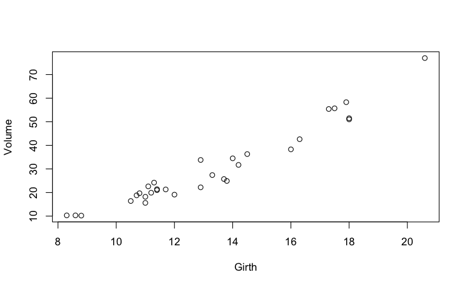

```r
plot(Volume ~ Girth, data=trees)
```

```r
mod.q <- lm(Volume ~ Girth + I(Girth^2) +
              Height + I(Height^2),
            data=trees)
summary(mod.q)
```

```
Call:
lm(formula = Volume ~ Girth + I(Girth^2) + Height + I(Height^2),
    data = trees)

Residuals:
   Min     1Q Median     3Q    Max
-4.368 -1.670 -0.158  1.792  4.358

Coefficients:
             Estimate Std. Error t value Pr(>|t|)
(Intercept) -0.955101  63.013630  -0.015    0.988
Girth       -2.796569   1.468677  -1.904    0.068 .
I(Girth^2)   0.265446   0.051689   5.135 2.35e-05 ***
Height       0.119372   1.784588   0.067    0.947
I(Height^2)  0.001717   0.011905   0.144    0.886
---
Signif. codes:  0 ‘***’ 0.001 ‘**’ 0.01 ‘*’ 0.05 ‘.’ 0.1 ‘ ’ 1

Residual standard error: 2.674 on 26 degrees of freedom
Multiple R-squared:  0.9771,    Adjusted R-squared:  0.9735
F-statistic:   277 on 4 and 26 DF,  p-value: < 2.2e-16
```

```r
# alternative code:
mod.q.poly <- lm(Volume ~ poly(Girth, 2, raw=TRUE) + poly(Height, 2, raw=TRUE), data=trees)
summary(mod.q.poly)
```

```
Call:
lm(formula = Volume ~ poly(Girth, 2, raw = TRUE) + poly(Height,
    2, raw = TRUE), data = trees)

Residuals:
   Min     1Q Median     3Q    Max
-4.368 -1.670 -0.158  1.792  4.358

Coefficients:
                              Estimate Std. Error t value Pr(>|t|)
(Intercept)                  -0.955101  63.013630  -0.015    0.988
poly(Girth, 2, raw = TRUE)1  -2.796569   1.468677  -1.904    0.068 .
poly(Girth, 2, raw = TRUE)2   0.265446   0.051689   5.135 2.35e-05 ***
poly(Height, 2, raw = TRUE)1  0.119372   1.784588   0.067    0.947
poly(Height, 2, raw = TRUE)2  0.001717   0.011905   0.144    0.886
---
Signif. codes:  0 ‘***’ 0.001 ‘**’ 0.01 ‘*’ 0.05 ‘.’ 0.1 ‘ ’ 1

Residual standard error: 2.674 on 26 degrees of freedom
Multiple R-squared:  0.9771,    Adjusted R-squared:  0.9735
F-statistic:   277 on 4 and 26 DF,  p-value: < 2.2e-16
```

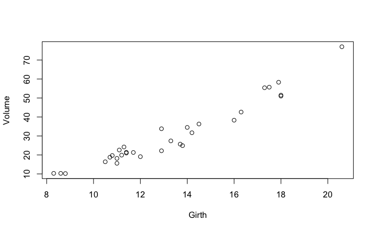

```r
plot(Volume ~ Girth, data=trees)
```

```r
mod.q <- lm(Volume ~ Girth + I(Girth^2) + Height , data=trees)
summary(mod.q)
```

```
Call:
lm(formula = Volume ~ Girth + I(Girth^2) + Height, data = trees)

Residuals:
    Min      1Q  Median      3Q     Max
-4.2928 -1.6693 -0.1018  1.7851  4.3489

Coefficients:
            Estimate Std. Error t value Pr(>|t|)
(Intercept) -9.92041   10.07911  -0.984 0.333729
Girth       -2.88508    1.30985  -2.203 0.036343 *
I(Girth^2)   0.26862    0.04590   5.852 3.13e-06 ***
Height       0.37639    0.08823   4.266 0.000218 ***
---
Signif. codes:  0 ‘***’ 0.001 ‘**’ 0.01 ‘*’ 0.05 ‘.’ 0.1 ‘ ’ 1

Residual standard error: 2.625 on 27 degrees of freedom
Multiple R-squared:  0.9771,    Adjusted R-squared:  0.9745
F-statistic: 383.2 on 3 and 27 DF,  p-value: < 2.2e-16
```

```r
AIC(mod.q)
```

```
[1] 153.5207
```

Perhaps the girth and height of the tree interact to influence its volume: investigate a model including an interaction term for the two explanatory variables.

```r
mod.int <- lm(Volume ~ Girth * Height, data=trees)
summary(mod.int)
```

```
Call:
lm(formula = Volume ~ Girth * Height, data = trees)

Residuals:
    Min      1Q  Median      3Q     Max
-6.5821 -1.0673  0.3026  1.5641  4.6649

Coefficients:
             Estimate Std. Error t value Pr(>|t|)
(Intercept)  69.39632   23.83575   2.911  0.00713 **
Girth        -5.85585    1.92134  -3.048  0.00511 **
Height       -1.29708    0.30984  -4.186  0.00027 ***
Girth:Height  0.13465    0.02438   5.524 7.48e-06 ***
---
Signif. codes:  0 ‘***’ 0.001 ‘**’ 0.01 ‘*’ 0.05 ‘.’ 0.1 ‘ ’ 1

Residual standard error: 2.709 on 27 degrees of freedom
Multiple R-squared:  0.9756,    Adjusted R-squared:  0.9728
F-statistic: 359.3 on 3 and 27 DF,  p-value: < 2.2e-16
```

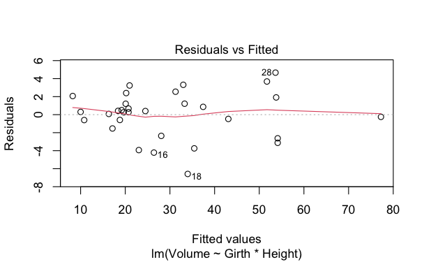

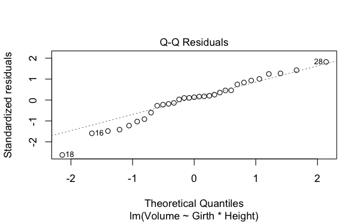

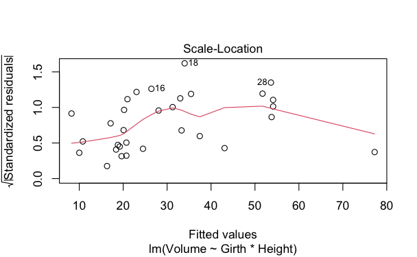

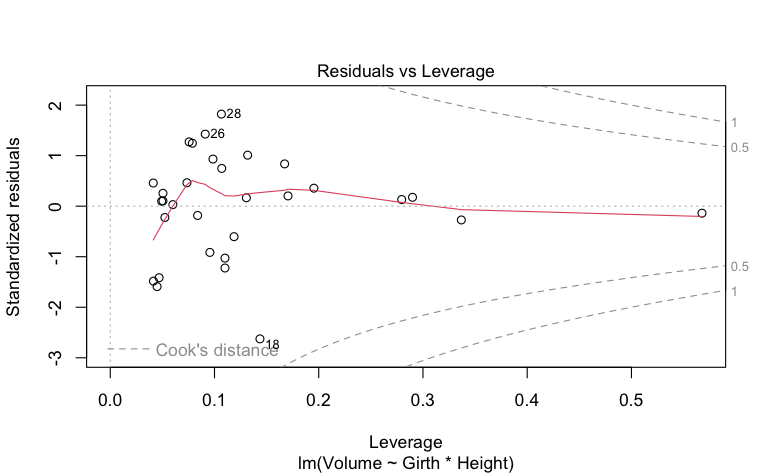

```r
mod <- lm(Volume ~ Girth * Height, data=trees)
plot(mod)
```

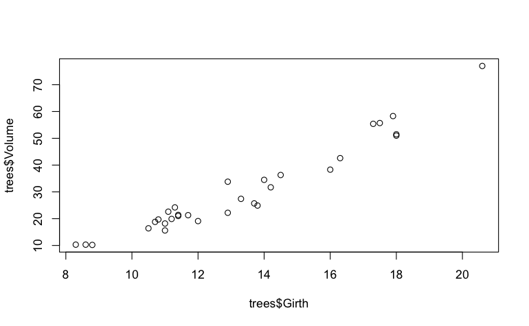

```r
plot(trees$Volume ~ trees$Girth)
```

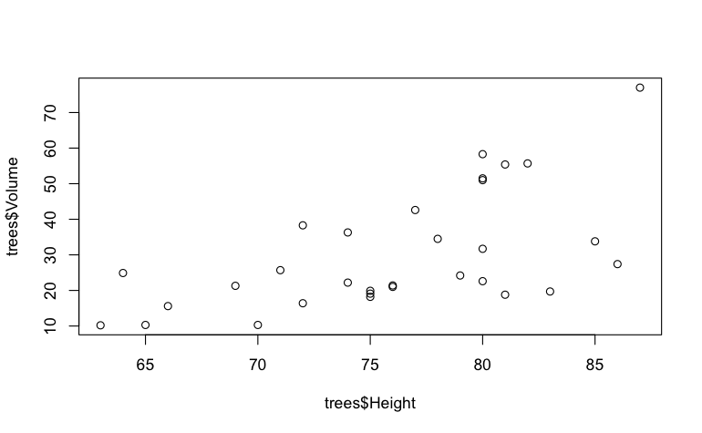

```r
plot(trees$Volume ~ trees$Height)
```

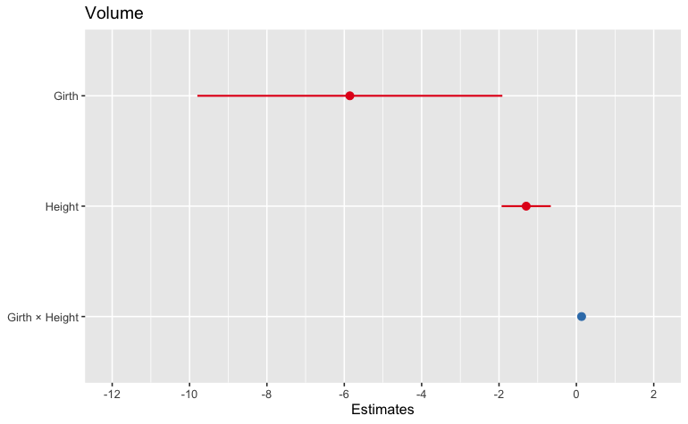

```r
library(sjPlot)
plot_model(mod)
```

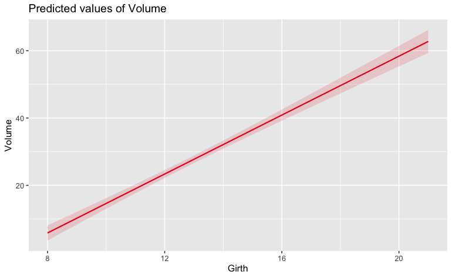

```r
plot_model(mod, type = "eff", terms = "Girth")
```

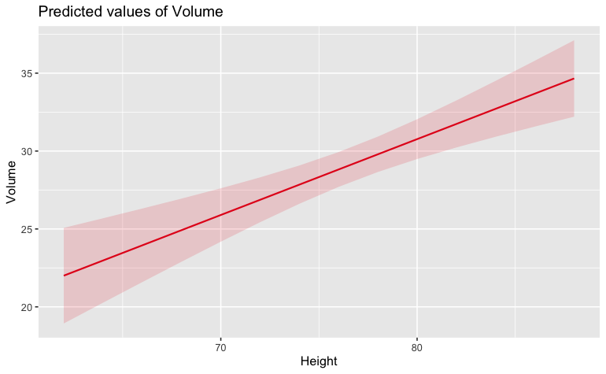

```r
plot_model(mod, type = "eff", terms = "Height")
```

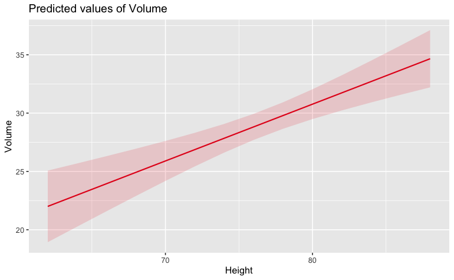

```r
plot_model(mod.int, type = "eff", terms = "Height")
```

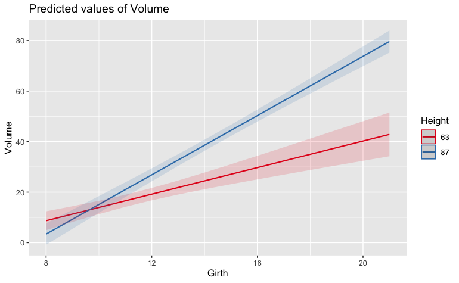

```r
plot_model(mod.int, type = "int", terms = c("Height","Girth")) # # type = "int" automatically selects groups for continuous moderator variables
```

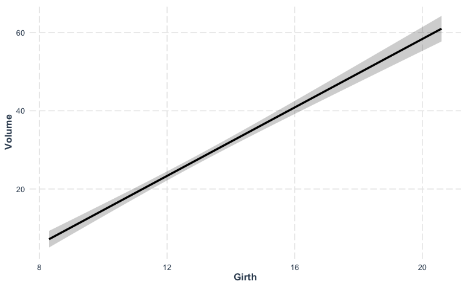

```r
library(jtools)
effect_plot(mod.int, pred = Girth, interval = TRUE)
```

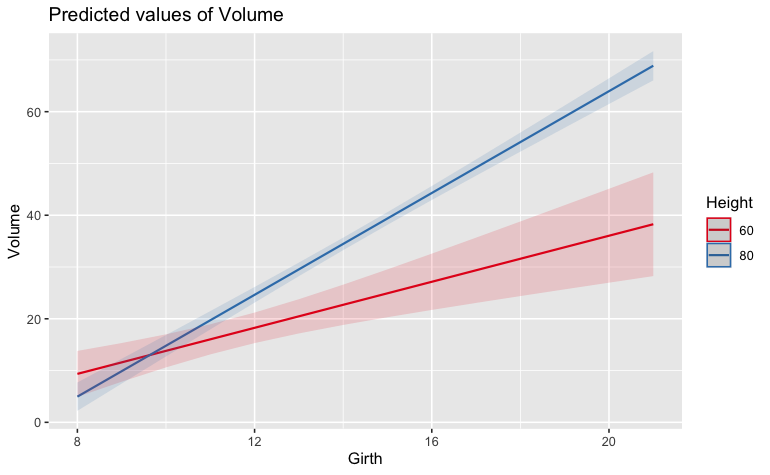

```r
plot_model(mod.int, type = "pred", terms = c("Girth", "Height [60,80]"))
```

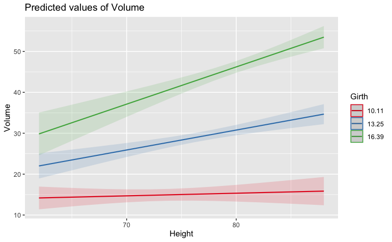

```r
# switch moderator
plot_model(mod.int, type = "pred", terms = c("Height", "Girth"))
```

```r
mod.poly.int <- lm(Volume ~ poly(Girth, 2, raw=TRUE) * Height, data=trees)
summary(mod.poly.int)
```

```
Call:
lm(formula = Volume ~ poly(Girth, 2, raw = TRUE) * Height, data = trees)

Residuals:
    Min      1Q  Median      3Q     Max
-5.1880 -0.7901 -0.0037  1.9306  3.9483

Coefficients:
                                    Estimate Std. Error t value Pr(>|t|)
(Intercept)                        48.914179  90.852925   0.538    0.595
poly(Girth, 2, raw = TRUE)1        -8.228180  13.803580  -0.596    0.556
poly(Girth, 2, raw = TRUE)2         0.311160   0.536379   0.580    0.567
Height                             -0.616152   1.250446  -0.493    0.626
poly(Girth, 2, raw = TRUE)1:Height  0.103075   0.180291   0.572    0.573
poly(Girth, 2, raw = TRUE)2:Height -0.001764   0.006621  -0.266    0.792

Residual standard error: 2.659 on 25 degrees of freedom
Multiple R-squared:  0.9782,    Adjusted R-squared:  0.9738
F-statistic: 224.3 on 5 and 25 DF,  p-value: < 2.2e-16
```

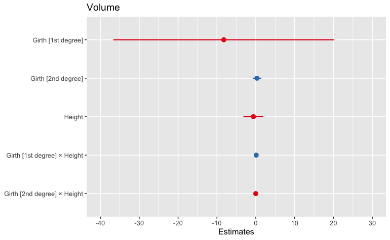

```r
plot_model(mod.poly.int)
```